# Dates and times - r4ds

2019-06-27

## Dates and Times

日付と時刻を扱う技術

### 準備

```r
library(tidyverse)
library(lubridate)

library(nycflights13)
```

## 前置き

- 一年は365日か？
- 一日は24時間か？
- 一分は60秒か？

日付や時刻は日常だから簡単と思うかもしれないが、本当はめちゃくちゃ難しい。

地球の**自転**と**公転**という二つの物理現象と地政学や歴史文化という人間的現象を同時に扱うため。

## 16.2 Creating date/times

日付と時刻データを作る

## データ型

日付と時刻を扱う三種類のclass

- date
- time
- datetime

timeを扱うためには追加で`hms`ライブラリが必要

### 原則

- dateで済むときはdatetimeは使わない
- datetimeで済むときはtimeは使わない

実際timeはほぼ必要ない

## 今

```r
today()
```

```
## [1] "2023-08-28"
```

```r
now()
```

```
## [1] "2023-08-28 14:56:31 JST"
```

## 16.2.1 From strings

単一の文字列や数値から日付データを作る

## 文字列から

```r
ymd("2017-01-31")
```

```
## [1] "2017-01-31"
```

```r
mdy("01-31-2017")
```

```
## [1] "2017-01-31"
```

### 当然ベクトル化されている

```r
ymd(c("2017-01-31", "2018-01-31"))
```

```
## [1] "2017-01-31" "2018-01-31"
```

## 数値からも作れる

```r
ymd(20170131)
```

```
## [1] "2017-01-31"
```

### 応用

```r
ymd(20170101 + 0:4 * 100)
```

```
## [1] "2017-01-01" "2017-02-01" "2017-03-01" "2017-04-01" "2017-05-01"
```

## 文字列からdatetimeも

```r
ymd_hms("2017-01-31 20:11:59")
```

```
## [1] "2017-01-31 20:11:59 UTC"
```

```r
ymd_hm("2017-01-31 20:11")
```

```
## [1] "2017-01-31 20:11:00 UTC"
```

## 16.2.2 From individual components

個別要素から日付データを作る

## `nycflights13`

```r
flights %>% select(year, month, day, hour, minute)
```

```
## # A tibble: 336,776 × 5
##     year month   day  hour minute
##    <int> <int> <int> <dbl>  <dbl>
##  1  2013     1     1     5     15
##  2  2013     1     1     5     29
##  3  2013     1     1     5     40
##  4  2013     1     1     5     45
##  5  2013     1     1     6      0
##  6  2013     1     1     5     58
##  7  2013     1     1     6      0
##  8  2013     1     1     6      0
##  9  2013     1     1     6      0
## 10  2013     1     1     6      0
## # … with 336,766 more rows
```

## `make_date`

```r
flights %>%
  select(year, month, day, hour, minute) %>%
  mutate(departure = make_datetime(year, month, day, hour, minute))
```

```
## # A tibble: 336,776 × 6
##     year month   day  hour minute departure
##    <int> <int> <int> <dbl>  <dbl> <dttm>
##  1  2013     1     1     5     15 2013-01-01 05:15:00
##  2  2013     1     1     5     29 2013-01-01 05:29:00
##  3  2013     1     1     5     40 2013-01-01 05:40:00
##  4  2013     1     1     5     45 2013-01-01 05:45:00
##  5  2013     1     1     6      0 2013-01-01 06:00:00
##  6  2013     1     1     5     58 2013-01-01 05:58:00
##  7  2013     1     1     6      0 2013-01-01 06:00:00
##  8  2013     1     1     6      0 2013-01-01 06:00:00
##  9  2013     1     1     6      0 2013-01-01 06:00:00
## 10  2013     1     1     6      0 2013-01-01 06:00:00
## # … with 336,766 more rows
```

## 時系列プロット

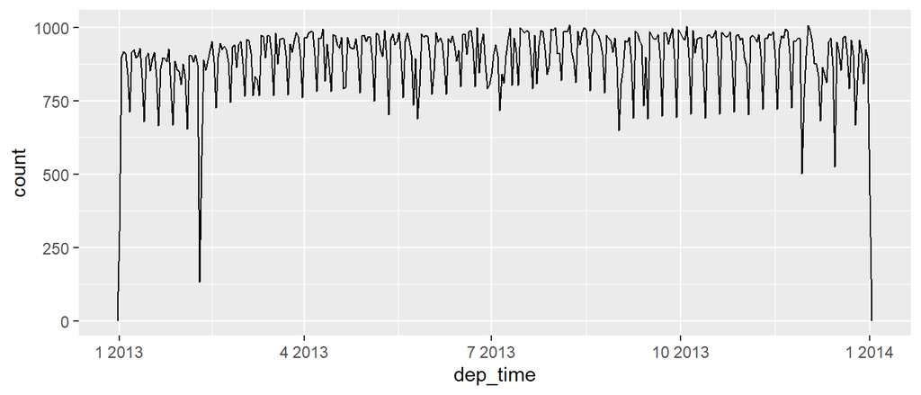

```r
flights_dt %>%
  ggplot(aes(dep_time)) +
    geom_freqpoly(binwidth = 60*60*24)
```

- 軸がdateだと単位は1日 / datetimeだと単位は1秒

## 16.2.3 From other types

date/datetime 変換

```r
as_datetime(today())
```

```
## [1] "2023-08-28 UTC"
```

```r
as_date(now())
```

```
## [1] "2023-08-28"
```

エポック時間からの生成

```r
as_date(365 * 10 + 2)
```

```
## [1] "1980-01-01"
```

## 練習問題

1~3

## 16.3 Datetime components

date/datetimeデータから必要な情報を取り出す技術

## 16.3.1 Getting Components

一部の要素を抜き出す

## 数字を抜き出す

```r
year(now())
```

```
## [1] 2023
```

```r
month(now())
```

```
## [1] 8
```

```r
yday(now())
```

```
## [1] 240
```

```r
wday(now())
```

```
## [1] 2
```

## カテゴリとして抽出

```r
month(now(), label = TRUE)
```

```
## [1] 8
## Levels: 1 < 2 < 3 < 4 < 5 < 6 < 7 < 8 < 9 < 10 < 11 < 12
```

```r
month(now(), label = TRUE, locale = "ja_JP.UTF-8")
```

```
## [1] 8
## Levels: 1 < 2 < 3 < 4 < 5 < 6 < 7 < 8 < 9 < 10 < 11 < 12
```

```r
wday(now(), label = TRUE, abbr = TRUE)
```

```
## [1] 月
## Levels: 日 < 月 < 火 < 水 < 木 < 金 < 土
```

ロケールの設定はシステムによって違うから注意

## 活用例

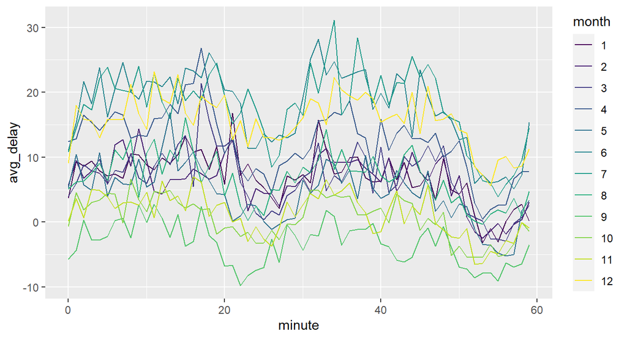

```r
flights_dt %>%
  mutate(minute = minute(dep_time), month = month(dep_time, label = TRUE)) %>%
  group_by(minute, month) %>%
  summarise(avg_delay = mean(arr_delay, na.rm = TRUE)) %>%
    ggplot(aes(minute, avg_delay)) + geom_line(aes(color = month))
```

## 16.3.2 Rounding

日付を丸める（下位の情報を捨てる）

- `floor_date` **重要！**
- `round_date`
- `ceiling_date`

## `floor_date`の使い方

```r
today()
```

```
## [1] "2023-08-28"
```

```r
floor_date(today(), "year")
```

```
## [1] "2023-01-01"
```

```r
floor_date(today(), "month")
```

```
## [1] "2023-08-01"
```

```r
floor_date(today(), "week", week_start = 1)
```

```
## [1] "2023-08-28"
```

## 日データを週でトレンド表示

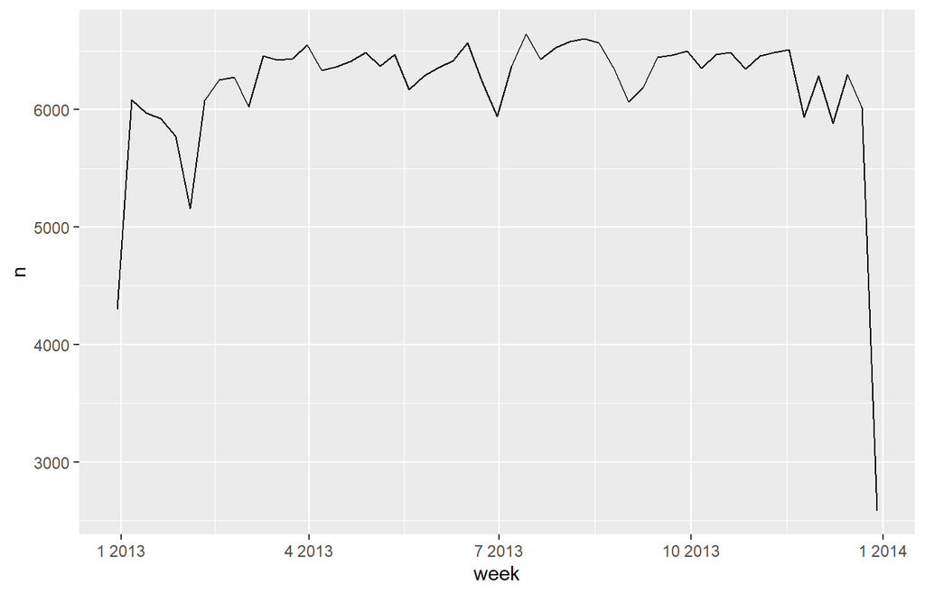

```r
flights_dt %>%
  count(week = floor_date(dep_time, "week")) %>%
  ggplot(aes(week, n)) + geom_line()
```

## 16.3.3 Setting components

要素を一部だけ変更する

関数`update`

## `update`

```r
today()
```

```
## [1] "2023-08-28"
```

```r
update(today(), year = 2020, month = 1)
```

```
## [1] "2020-01-28"
```

実は`update`は日付以外でも使える汎用的な関数

## 短い尺度で見る

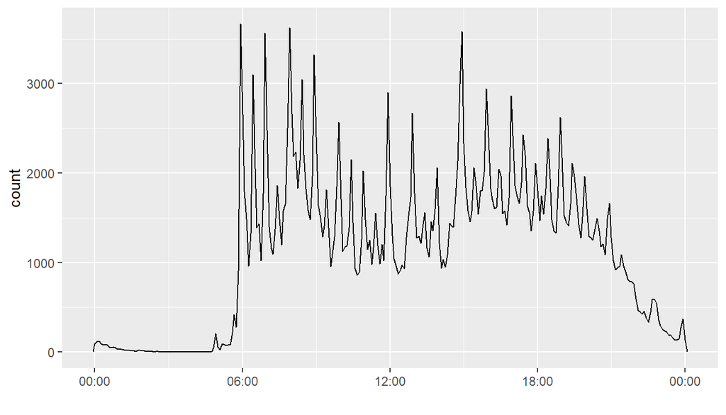

```r
flights_dt %>%
  mutate(dep_hour = update(dep_time, yday = 1)) %>%
  ggplot(aes(dep_hour)) + geom_freqpoly(binwidth = 300) +
    scale_x_datetime(date_labels = "%H:%M", name = "")
```

## 練習問題

1~7

## 16.4 Time spans

時間の計算(差を取ったり比を取ったり)

- durations
- periods
- intervals

## 16.4.1 Durations

秒で時間を測るやり方

## durationの生成

```r
dseconds(15)
```

```
## [1] "15s"
```

```r
dhours(0.5)
```

```
## [1] "1800s (~30 minutes)"
```

```r
as.duration(ymd(20190101) - ymd(20180101))
```

```
## [1] "31536000s (~52.14 weeks)"
```

他にも`dminutes`, `ddays`, `dyears`など

## durationの計算

```r
dyears(1) + dweeks(1) - ddays(1)
```

```
## [1] "32076000s (~1.02 years)"
```

```r
dhours(1) / 2
```

```
## [1] "1800s (~30 minutes)"
```

```r
ymd(20190101) + ddays(1)
```

```
## [1] "2019-01-02"
```

## duration利用上の注意

計算結果が人間の感覚と合わない場合がある

```r
ymd(20200101) + dyears(1)
```

```
## [1] "2020-12-31 06:00:00 UTC"
```

`dmonths`は無い

## 16.4.2 Periods

人間的に時間を測るやり方

## periodsの生成

```r
seconds(15)
```

```
## [1] "15S"
```

```r
months(2)
```

```
## [1] "2m 0d 0H 0M 0S"
```

```r
years(1)
```

```
## [1] "1y 0m 0d 0H 0M 0S"
```

- 単位ごとに数字を持っていることに注目
- 整数しか持てない

## periodsの計算

```r
years(1) + weeks(1) - days(1)
```

```
## [1] "1y 0m 6d 0H 0M 0S"
```

```r
days(2) * 500
```

```
## [1] "1000d 0H 0M 0S"
```

```r
ymd(20200101) + years(1)
```

```
## [1] "2021-01-01"
```

## durationとperiodの比較

```r
dyears(1) - ddays(365)
```

```
## [1] "21600s (~6 hours)"
```

```r
years(1) - days(365)
```

```
## [1] "1y 0m -365d 0H 0M 0S"
```

## periodの実用例

```r
flights_dt <- flights_dt %>%
  mutate(
    overnight = arr_time < dep_time,
    arr_time = arr_time + days(overnight * 1),
    sched_arr_time = sched_arr_time + days(overnight * 1)
  )
```

## 16.4.3 Intervals

期間を定義し計算する方法

正直実戦で使ったこと無い

## intervalの生成

```r
intervals <- ymd(20200101) %--% ymd(20210101)
intervals
```

```
## [1] 2020-01-01 UTC--2021-01-01 UTC
```

## intervalsの計算

```r
intervals / ddays(1)
```

```
## [1] 366
```

```r
intervals / days(1)
```

```
## [1] 366
```

```r
intervals / dyears(1)
```

```
## [1] 1.002053
```

```r
intervals / years(1)
```

```
## [1] 1
```

## 16.4.4 Summary

## 練習問題

1~5

## 16.5 Time zones

タイムゾーン、すなわち時差の扱い。

## 考え方

- タイムゾーンは国ごとに定義できない
  - 一つの国でも異なるタイムゾーンが利用される場合あり
  - 異なる国でも同じタイムゾーンが利用される場合あり
- タイムゾーンは都市ごとに定義する
  - 長期でみて国名が頻繁に変わるのに大して都市名は変わりにくい

### あなたのタイムゾーン

```r
Sys.timezone()
```

```
## [1] "Asia/Tokyo"
```

## タイムゾーンの設定

```r
ymd_hm(201901010100)
```

```
## [1] "2019-01-01 01:00:00 UTC"
```

```r
ymd_hm(201901010100, tz = "Japan")
```

```
## [1] "2019-01-01 01:00:00 JST"
```

```r
now()
```

```
## [1] "2023-08-28 14:56:50 JST"
```

- デフォルトではUTC
- `now`は自動的にRに設定されているタイムゾーンをセットする

## 時間差の計算

```r
# ほぼゼロ
now() - now(tz = "America/New_York")
```

```
## Time difference of -0.0001049042 secs
```

```r
# tzを合わせれば時差が計算できる
ny_now <- now(tz = "America/New_York")
now() - force_tz(ny_now, tzone = "Japan")
```

```
## Time difference of 13 hours
```

## 参考情報

- [IANA timezones](https://www.iana.org/time-zones)